# Your Digest for Wednesday, Apr 10, 2024 11:59 PM

[[SupraventricularTachycardias.pdf]]

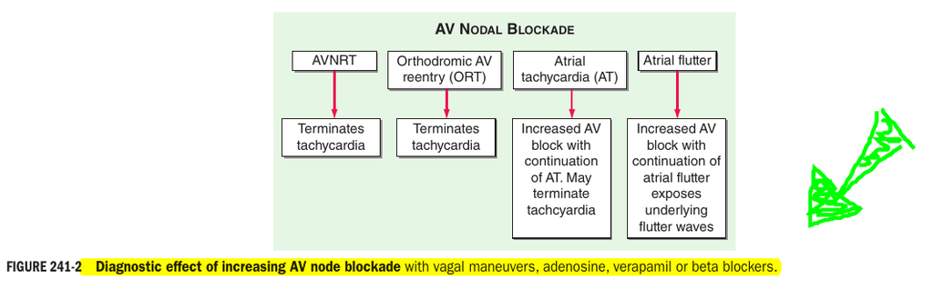

> [!INFO] Thiazide like diuretics  
> Metolazone, indapamide, and chlorthalidone

#### Blood pressure targets:

Age Group

**Clinic BP**

**ABPM / HBPM**

**Age < 80 years**

140/90 mmHg

135/85 mmHg

**Age > 80 years**

150/90 mmHg

145/85 mmHg

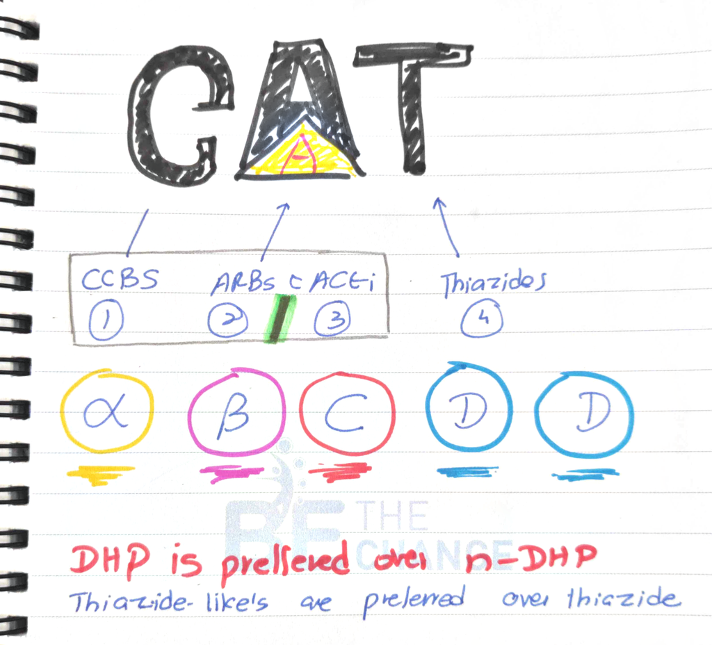

> [!TIP] first line antihypertensives - CATA

[figure not shown]

> Hydraulics -> pressure  
> everything else -> beta blockers, loop diuretics, K+ sparing diuretics, alpha blockers, vasolidators, direct renin inhibitors (eg. *Aliskiren*)

### Management of resistant hypertension.

- Add low dose spironolactone (esp if K+ < 4.5)
- If K+ > 4.5, consider alpha or beta blocker.

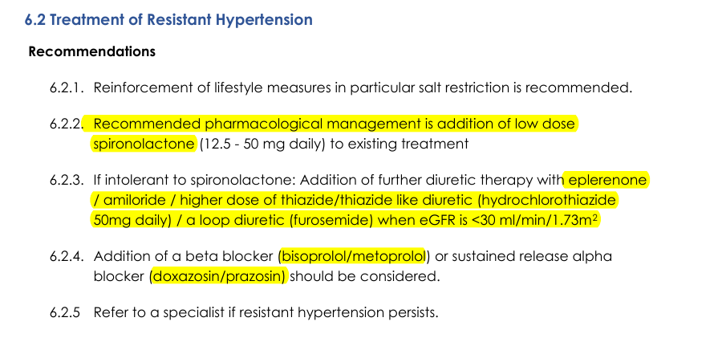

### Pharmacologic options for Anticoagulation

- DOACS are preferred except in the following scenarios
  1. Rheumatic Mitral stenosis causing AF (DOACS had higher morbidity and INVICTUS trial)
  2. Mechanical heart valve prosthesis in situ
  3. DOAC interactions with other drugs
     1. Chronic antiviral therapy can increase DOAC anticoagulant activity.
     2. P-glycoprotein inducers can increase DOAC efflux from guy and reduce anticoagulant activity
- The side effect is **idiosyncratic**. It can happen at any time. **No point in monitoring for it!**
- Ask the patient to come to hospital if *symptoms occur*. In contrast to drugs like ?clozapine => progressive neutropenia

[output not shown]

> - The sulfonylureas are **strongly protein bound,** particularly to albumin. Thus, *elevated plasma drug levels cannot be efficiently reversed by hemodialysis.* Furthermore, *displacement* of these drugs from albumin by *beta blockers, salicylates, and warfarin* can lead to hypoglycemia due to increased plasma concentration of the free sulfonylurea.

# Heparin induced thrombocytopaenia

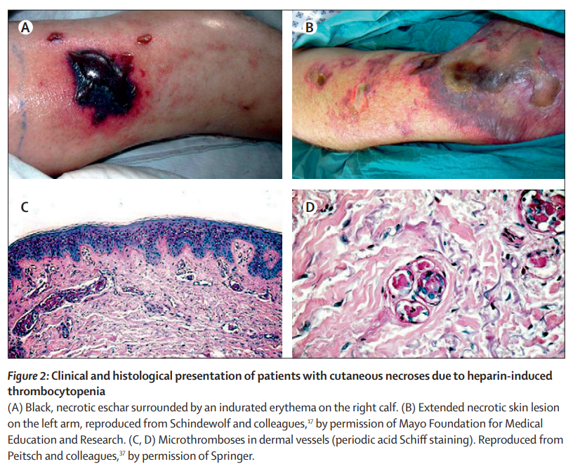

> - Antibodies are produced against **heparin-platelet factor 4** complexes.
> - This is found on platelets and endothelial cells. *Circulating immune complexes bind to platelet* (thrombocytopaenia) and blood vessels (endothelial damage) and can *result in **DIC***.
- **Antibodies bind to PF4 on the platelet surface** and stimulate **platelet activation**.
- This results in **thrombocytopaenia** (platelets found to to antibodies are removed by the Reticuloendothelial system) - commonest manifestation.
- Associated ⭐**thrombosis** (venous more than arterial) - around 50%, if untreated.
  - Manifestations include *pulmonary embolism*, *skin necrosis*, *limb gangrene*.
  - **Arterial thrombi** (MI, stroke) can also occur.
- **Bleeding is rare!**
- **Onset** is 5 - 10 days after onset of therapy.
- Risk with Heparin > risk with LMWH (fractionated heparin)
- Risk with High dose > risk with low dose

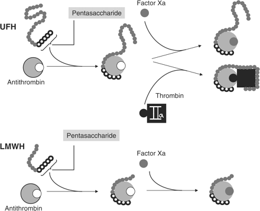

- "4 T" score is used to assess the likelihood of HIT.
  - Points are assigned based on
  1. Severity of thrombocytopenia
  2. Timing of thrombocytopenia
  3. Presence of Thrombosis of other sequelae
  4. Thrombocytopaenia due to other reasons
- **Treatment**: Stop heparin and start *non heparin anti-coagulation* (like a *direct thrombin inhibitor*)
- #2021GM-JUL/Q25

Strategies are different for mechanical valves and bioprosthetic valves.  
[Source](https://www.escardio.org/Journals/E-Journal-of-Cardiology-Practice/Volume-20/prosthetic-heart-valves-part-2-antithrombotic-management)

- Depends on the which valve is replaced, which type of mechanical valve is used and presence of other thromboembolic risk factors.
- *All mechanical valves require **lifelong** anticoagulation with **Vitamin K agonist***.
- There is now ❌**NO RECOMMENDATION**❌ for giving antiplatelets along with VKAs for thromboprophylaxis with *mechanical valves*.
- So far, the **only option for anticoagulation** with mechanical heart valves is **warfarin**.
- **Target INR is 2.5 for 3 to 6 months** if there are no other reasons to anticoagulate **using a VKA**.
  - This is because the first 90-180 days are considered high risk.
- All patients (with no other indication for anticoagulation) **get aspirin** after the period of anticoagulation.

> [!TIP] Only indication for *intra-venous* vitamin K (and PCC) is
> - Life threatening bleeding

#2021BSQ-NOV/Q36